# Chron’s Disease DESeq analysis

#### **Heatmap**

Clustered heatmaps, after removing Batch effect of Gender, are plotted over Disease.State and Gender using the 20 most variant genes among samples.

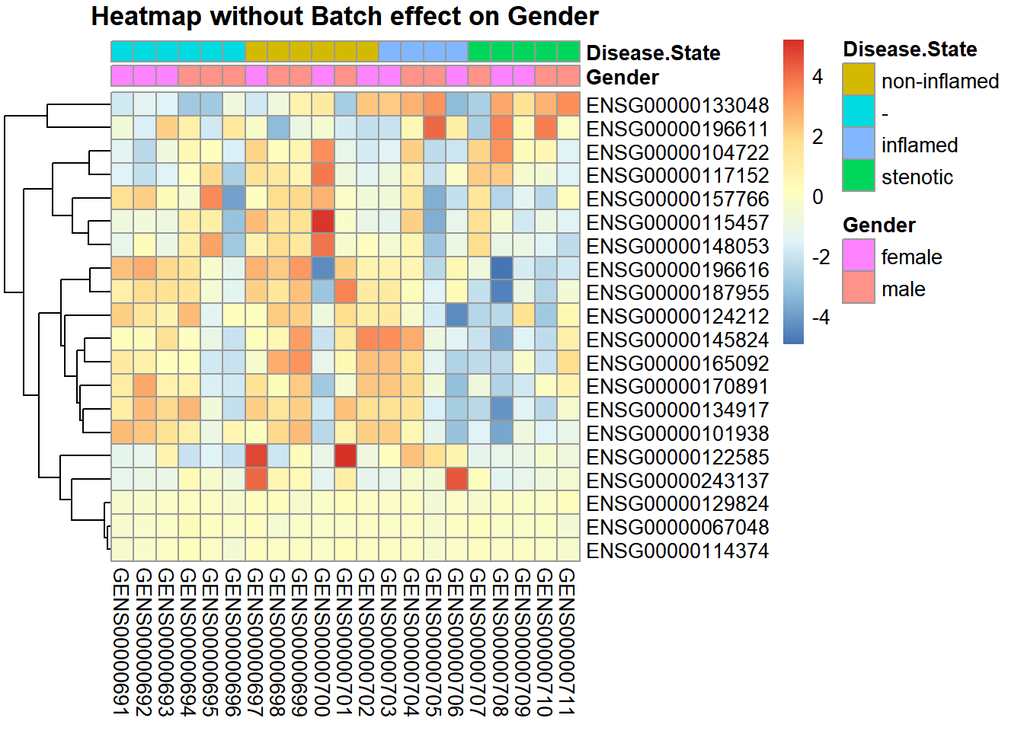

```r
#Most variant genes among samples
topVarGenes2 <- order(rowVars(assay(rld2)),decreasing=TRUE)
mat2 <- assay(rld2)[topVarGenes2, ]
mat2 <- mat2 - rowMeans(mat2)
new_mat2 <- removeBatchEffect(mat2, batch= colData(rld2)$Gender)

df_clust2 <- as.data.frame(colData(rld2)[,c("Gender","Disease.State")])
pheatmap(head(new_mat2, 20), annotation_col=df_clust2, main = "Heatmap without Batch effect on Gender", cluster_cols = F)
```

Clustered heatmaps, after removing Batch effect of Gender, are plotted over Disease.State and Gender using the most significantly DE genes among samples.

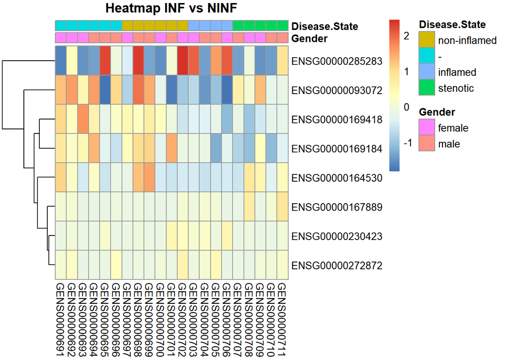

```r
#Most significantly DE genes
#IN
res2_inf_noninf_LFC <- res2_inf_noninf[order(abs(res2_inf_noninf$log2FoldChange), decreasing = T),]
topDEGenes2_IN <- new_mat2[rownames(res2_inf_noninf_LFC),]
pheatmap(topDEGenes2_IN, annotation_col=df_clust2, main = "Heatmap INF vs NINF", cluster_cols = F)
```

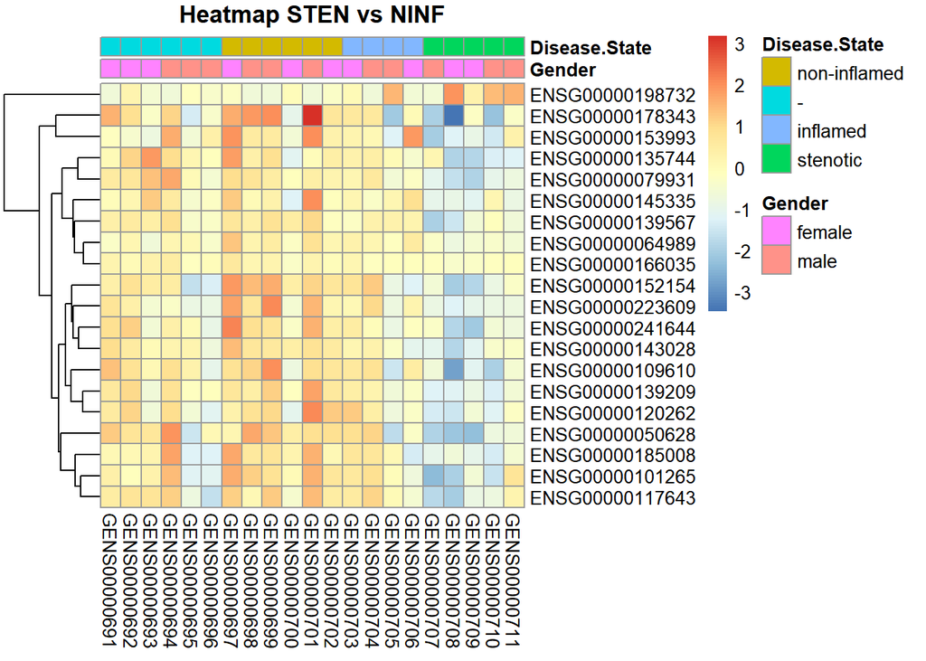

```r
#SN
res2_sten_noninf_LFC <-res2_sten_noninf[order(abs(res2_sten_noninf$log2FoldChange),
                                               decreasing = T),]
topDEGenes2_SN <- new_mat2[rownames(res2_sten_noninf_LFC),]
pheatmap(head(topDEGenes2_SN,20), annotation_col=df_clust2, main = "Heatmap STEN vs NINF", cluster_cols = F)
```

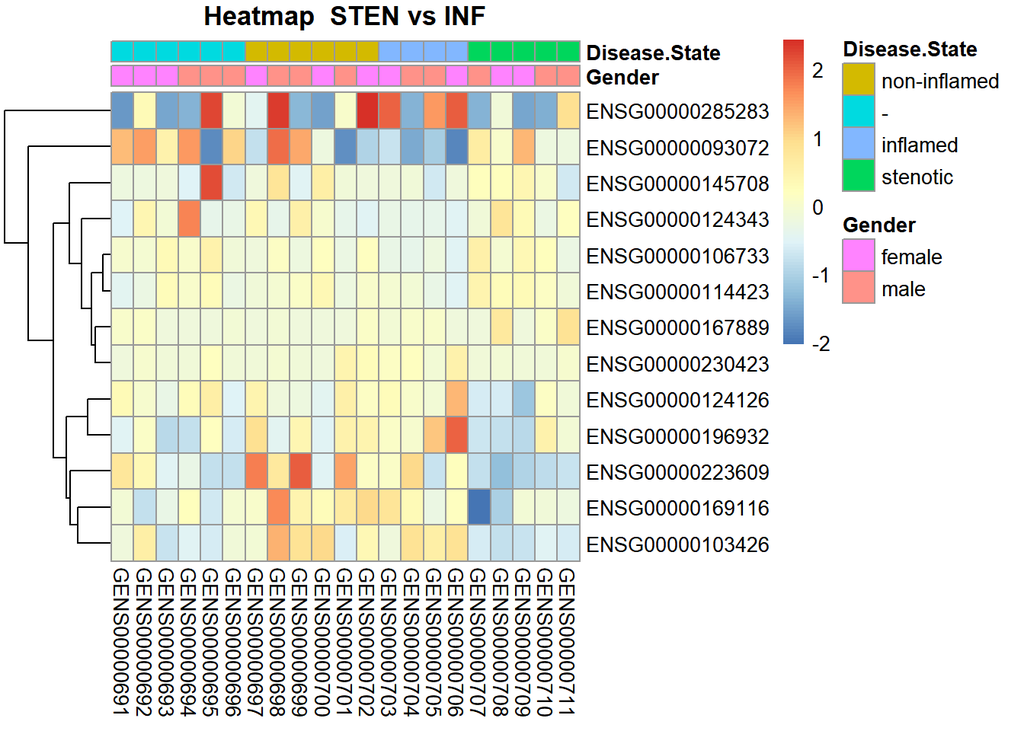

```r
#SI
res2_sten_inf_LFC <-res2_sten_inf[order(abs(res2_sten_inf$log2FoldChange),
                                               decreasing = T),]
topDEGenes2_SI <- new_mat2[rownames(res2_sten_inf_LFC),]
pheatmap(topDEGenes2_SI, annotation_col=df_clust2, main = "Heatmap  STEN vs INF", cluster_cols = F)
```

### Enrichment

Once the differentially expressed genes have been identified, enrichment analysis can be used to identify the biological pathways, gene ontology terms, or functional categories that are more common in the list of DE genes.

Enrichment analysis is performed using two databases: **Gene Ontology (GO)** and **Kyoto Encyclopedia of Genes and Genomes (KEGG)**.

```r
geneList_DESeq2_IN <- res2_inf_noninf$log2FoldChange
names(geneList_DESeq2_IN) <- rownames(res2_inf_noninf)

geneList_DESeq2_SN <- res2_sten_noninf$log2FoldChange
names(geneList_DESeq2_SN) <- rownames(res2_sten_noninf)


geneList_DESeq2_SI <- res2_sten_inf$log2FoldChange
names(geneList_DESeq2_SI) <- rownames(res2_sten_inf)
```

#### **Gene Ontology (GO)**

```r
#INF VS NINF
#Molecular Function
ego2MF_IN <- enrichGO(gene = names(geneList_DESeq2_IN), OrgDb = org.Hs.eg.db,
                   keyType = 'ENSEMBL', ont = "MF", pAdjustMethod = "BH",
                   pvalueCutoff  = 0.1, readable = T)

head(ego2MF_IN)
```

```
##                    ID
## GO:0004000 GO:0004000
## GO:0009975 GO:0009975
## GO:0016849 GO:0016849
## GO:0140103 GO:0140103
## GO:0019239 GO:0019239
## GO:0016814 GO:0016814
##                                                                                          Description
## GO:0004000                                                              adenosine deaminase activity
## GO:0009975                                                                          cyclase activity
## GO:0016849                                                          phosphorus-oxygen lyase activity
## GO:0140103                                              catalytic activity, acting on a glycoprotein
## GO:0019239                                                                        deaminase activity
## GO:0016814 hydrolase activity, acting on carbon-nitrogen (but not peptide) bonds, in cyclic amidines
##            GeneRatio  BgRatio      pvalue   p.adjust     qvalue geneID Count
## GO:0004000       1/5 13/20758 0.003127704 0.04113729 0.01587755   ADA2     1
## GO:0009975       1/5 23/20758 0.005528301 0.04113729 0.01587755   NPR1     1
## GO:0016849       1/5 24/20758 0.005768106 0.04113729 0.01587755   NPR1     1
## GO:0140103       1/5 28/20758 0.006726864 0.04113729 0.01587755 MGAT5B     1
## GO:0019239       1/5 34/20758 0.008163614 0.04113729 0.01587755   ADA2     1
## GO:0016814       1/5 37/20758 0.008881365 0.04113729 0.01587755   ADA2     1
```

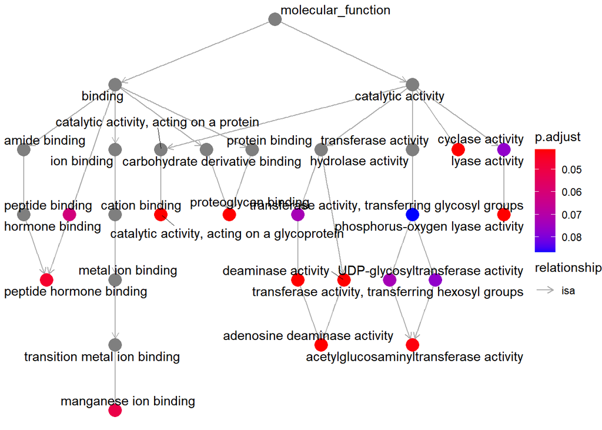

```r
goplot(ego2MF_IN)
```

```r
#Cellular Components
ego2CC_IN <- enrichGO(gene = names(geneList_DESeq2_IN), OrgDb = org.Hs.eg.db,
                   keyType = 'ENSEMBL', ont = "CC", pAdjustMethod = "BH",
                   pvalueCutoff  = 0.1, readable = T)

head(ego2CC_IN)
```

```
##                    ID               Description GeneRatio   BgRatio     pvalue
## GO:0035578 GO:0035578   azurophil granule lumen       1/5 106/22283 0.02356183
## GO:0005766 GO:0005766          primary lysosome       1/5 173/22283 0.03822411
## GO:0042582 GO:0042582         azurophil granule       1/5 173/22283 0.03822411
## GO:0005775 GO:0005775            vacuolar lumen       1/5 209/22283 0.04602928
## GO:0034774 GO:0034774   secretory granule lumen       1/5 375/22283 0.08136704
## GO:0060205 GO:0060205 cytoplasmic vesicle lumen       1/5 378/22283 0.08199590
##              p.adjust     qvalue geneID Count
## GO:0035578 0.08055124 0.03633891   ADA2     1
## GO:0005766 0.08055124 0.03633891   ADA2     1
## GO:0042582 0.08055124 0.03633891   ADA2     1
## GO:0005775 0.08055124 0.03633891   ADA2     1
## GO:0034774 0.08241494 0.03717967   ADA2     1
## GO:0060205 0.08241494 0.03717967   ADA2     1
```

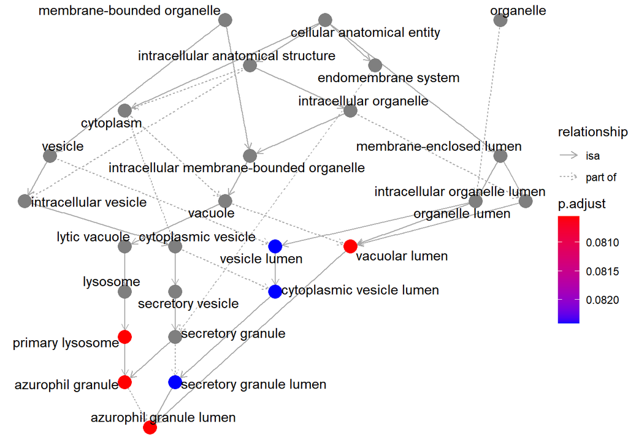

```r
goplot(ego2CC_IN)
```

```r
#Biological Process
ego2BP_IN <- enrichGO(gene = names(geneList_DESeq2_IN), OrgDb = org.Hs.eg.db,
                   keyType = 'ENSEMBL', ont = "BP", pAdjustMethod = "BH",
                   pvalueCutoff  = 0.1, readable = T)

head(ego2BP_IN)
```

```
##                    ID                                     Description GeneRatio
## GO:0030308 GO:0030308              negative regulation of cell growth       2/5
## GO:0045926 GO:0045926                   negative regulation of growth       2/5
## GO:0072522 GO:0072522 purine-containing compound biosynthetic process       2/5
## GO:0007168 GO:0007168     receptor guanylyl cyclase signaling pathway       1/5
## GO:0018242 GO:0018242       protein O-linked glycosylation via serine       1/5
## GO:0046085 GO:0046085                     adenosine metabolic process       1/5
##              BgRatio       pvalue   p.adjust      qvalue    geneID Count
## GO:0030308 212/21069 0.0009878043 0.02627393 0.007509454 PI16/NPR1     2
## GO:0045926 274/21069 0.0016420819 0.02627393 0.007509454 PI16/NPR1     2
## GO:0072522 279/21069 0.0017018571 0.02627393 0.007509454 ADA2/NPR1     2
## GO:0007168  10/21069 0.0023711281 0.02627393 0.007509454      NPR1     1
## GO:0018242  10/21069 0.0023711281 0.02627393 0.007509454    MGAT5B     1
## GO:0046085  10/21069 0.0023711281 0.02627393 0.007509454      ADA2     1
```

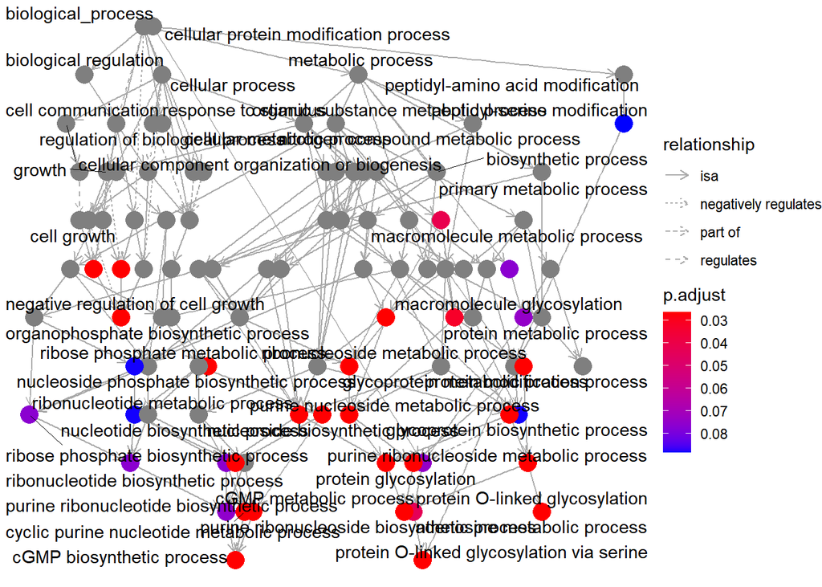

```r
goplot(ego2BP_IN)
```

```r
#STEN VS NINF
#Molecular Function
ego2MF_SN <- enrichGO(gene = names(geneList_DESeq2_SN), OrgDb = org.Hs.eg.db,
                      keyType = 'ENSEMBL', ont = "MF", pAdjustMethod = "BH",
                      pvalueCutoff  = 0.1, readable = T)

head(ego2MF_SN)
```

```
##                    ID                                 Description GeneRatio
## GO:0005539 GO:0005539                   glycosaminoglycan binding    27/402
## GO:0008201 GO:0008201                             heparin binding    22/402
## GO:0005201 GO:0005201 extracellular matrix structural constituent    22/402
## GO:0005178 GO:0005178                            integrin binding    17/402
## GO:1901681 GO:1901681                     sulfur compound binding    22/402
## GO:0019838 GO:0019838                       growth factor binding    14/402
##              BgRatio       pvalue     p.adjust       qvalue
## GO:0005539 262/20758 1.674281e-12 1.166974e-09 1.053916e-09
## GO:0008201 196/20758 3.761654e-11 1.179996e-08 1.065676e-08
## GO:0005201 199/20758 5.078891e-11 1.179996e-08 1.065676e-08
## GO:0005178 168/20758 3.094197e-08 5.391637e-06 4.869288e-06
## GO:1901681 296/20758 8.499719e-08 1.184861e-05 1.070070e-05
## GO:0019838 143/20758 7.688710e-07 8.931719e-05 8.066401e-05
##                                                                                                                                                           geneID
## GO:0005539 SMOC1/CCL7/COMP/APLP2/ECM2/CCN5/LAYN/VTN/TWSG1/RSPO2/PCSK6/ADAMTS8/PTN/FGFR1/DCN/EXTL2/ADAMTS5/BMP4/LTBP4/FGFR4/CFH/HAPLN1/TNXB/GREM2/SLIT3/LIPC/SOD3
## GO:0008201                             SMOC1/CCL7/COMP/APLP2/ECM2/CCN5/VTN/TWSG1/RSPO2/PCSK6/ADAMTS8/PTN/FGFR1/ADAMTS5/BMP4/FGFR4/CFH/TNXB/GREM2/SLIT3/LIPC/SOD3
## GO:0005201                        COL7A1/ASPN/COMP/COL5A2/FBLN2/VTN/DCN/EFEMP1/EMILIN2/LTBP4/FBN2/THSD4/FBLN5/COL14A1/MGP/LAMA3/HAPLN1/FBLN1/TNXB/LUM/FGL2/MFAP4
## GO:0005178                                                      COMP/ECM2/CCN5/CX3CL1/JAM2/VTN/ADAMTS8/PTN/F11R/ITGA8/ADAMTS5/LTBP4/PLPP3/FBLN5/LAMA3/FBLN1/TNXB
## GO:1901681                             SMOC1/CCL7/COMP/APLP2/ECM2/CCN5/VTN/TWSG1/RSPO2/PCSK6/ADAMTS8/PTN/FGFR1/ADAMTS5/BMP4/FGFR4/CFH/TNXB/GREM2/SLIT3/LIPC/SOD3
## GO:0019838                                                                   NGFR/IGFBP5/IL6ST/NKD2/TWSG1/PCSK6/FGFR1/IL6R/CHRDL1/LTBP4/FGFR4/KAZALD1/GHR/ACVRL1
##            Count
## GO:0005539    27
## GO:0008201    22
## GO:0005201    22
## GO:0005178    17
## GO:1901681    22
## GO:0019838    14
```

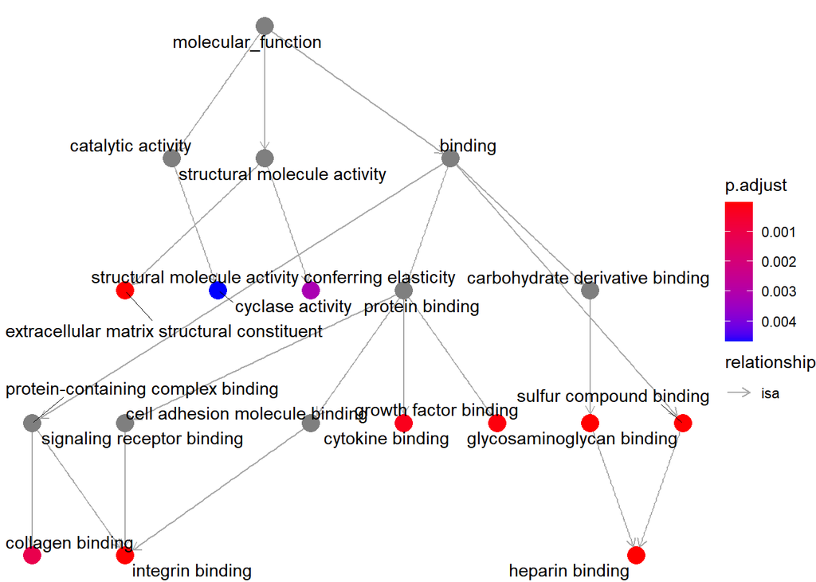

```r
goplot(ego2MF_SN)
```

```r
#Cellular Components
ego2CC_SN <- enrichGO(gene = names(geneList_DESeq2_SN), OrgDb = org.Hs.eg.db,
                      keyType = 'ENSEMBL', ont = "CC", pAdjustMethod = "BH",
                      pvalueCutoff  = 0.1, readable = T)

head(ego2CC_SN)
```

[output not shown]

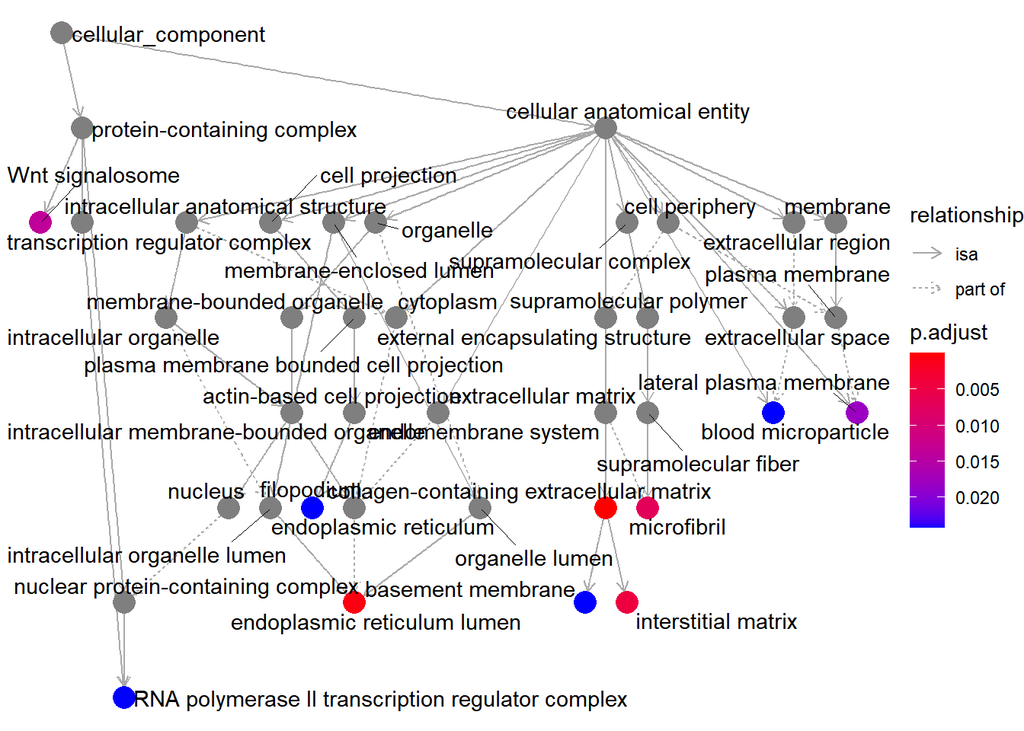

```r
goplot(ego2CC_SN)
```

```r
#Biological Process
ego2BP_SN <- enrichGO(gene = names(geneList_DESeq2_SN), OrgDb = org.Hs.eg.db,
                      keyType = 'ENSEMBL', ont = "BP", pAdjustMethod = "BH",
                      pvalueCutoff  = 0.1, readable = T)

head(ego2BP_SN)
```

```
##                    ID                                   Description GeneRatio
## GO:0030198 GO:0030198             extracellular matrix organization    26/395
## GO:0043062 GO:0043062          extracellular structure organization    26/395
## GO:0001503 GO:0001503                                  ossification    30/395
## GO:0045229 GO:0045229 external encapsulating structure organization    26/395
## GO:0001822 GO:0001822                            kidney development    23/395
## GO:0001763 GO:0001763        morphogenesis of a branching structure    19/395
##              BgRatio       pvalue     p.adjust       qvalue
## GO:0030198 367/21069 7.764036e-09 1.030901e-05 8.424799e-06
## GO:0043062 368/21069 8.212447e-09 1.030901e-05 8.424799e-06
## GO:0001503 477/21069 8.492871e-09 1.030901e-05 8.424799e-06
## GO:0045229 371/21069 9.707167e-09 1.030901e-05 8.424799e-06
## GO:0001822 329/21069 7.355233e-08 6.249006e-05 5.106855e-05
## GO:0001763 233/21069 9.457768e-08 6.382578e-05 5.216013e-05
##                                                                                                                                                                            geneID
## GO:0030198      SMOC1/COMP/ECM2/COL5A2/ADAMTSL3/FBLN2/SLC2A10/VTN/PDPN/MYH11/RECK/ADAMTS8/ADAMTSL4/QSOX1/ITGA8/ADAMTS5/FGFR4/THSD4/KAZALD1/FBLN5/COL14A1/FBLN1/TNXB/LUM/MFAP4/AGT
## GO:0043062      SMOC1/COMP/ECM2/COL5A2/ADAMTSL3/FBLN2/SLC2A10/VTN/PDPN/MYH11/RECK/ADAMTS8/ADAMTSL4/QSOX1/ITGA8/ADAMTS5/FGFR4/THSD4/KAZALD1/FBLN5/COL14A1/FBLN1/TNXB/LUM/MFAP4/AGT
## GO:0001503 SMOC1/FBL/SOX11/CBFB/ALPL/MAPK14/ASPN/COMP/NPR2/COL5A2/IGFBP5/IL6ST/JUND/PBX1/TWSG1/RSPO2/CSF1/OSR2/PTN/SEMA4D/IL6R/CHRDL1/PPARG/BMP4/JUNB/FBN2/KAZALD1/MGP/MN1/RASSF2
## GO:0045229      SMOC1/COMP/ECM2/COL5A2/ADAMTSL3/FBLN2/SLC2A10/VTN/PDPN/MYH11/RECK/ADAMTS8/ADAMTSL4/QSOX1/ITGA8/ADAMTS5/FGFR4/THSD4/KAZALD1/FBLN5/COL14A1/FBLN1/TNXB/LUM/MFAP4/AGT
## GO:0001822                                SOX11/RDH10/PKD1/PBX1/GLIS2/HOXA11/CYP26B1/SPRY1/OSR2/EGR1/TEK/ITGA8/TCF21/IL6R/EDNRB/PDGFD/BMP4/SERPINF1/WNT2B/PCSK5/TACSTD2/ROBO2/AGT
## GO:0001763                                                             ERMN/WNT2/RDH10/PKD1/PBX1/ADM/HOXA11/RSPO2/CSF1/SPRY1/FGF13/TCF21/BMP4/GDF7/SEMA3E/WNT2B/SOCS3/TACSTD2/AGT
##            Count
## GO:0030198    26
## GO:0043062    26
## GO:0001503    30
## GO:0045229    26
## GO:0001822    23
## GO:0001763    19
```

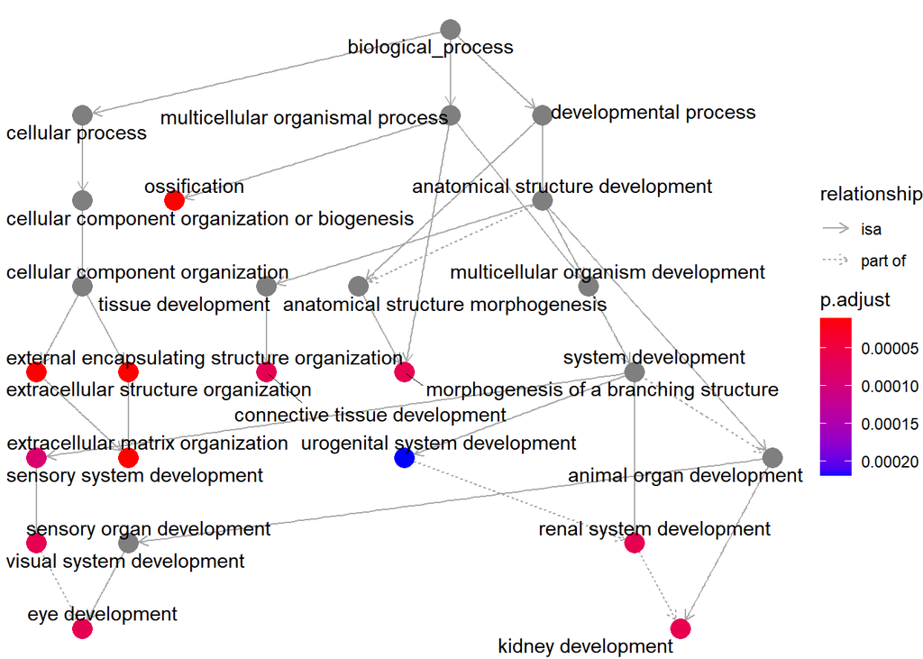

```r
goplot(ego2BP_SN)
```

```r
#STEN VS INF
#Molecular Function
ego2MF_SI <- enrichGO(gene = names(geneList_DESeq2_SI), OrgDb = org.Hs.eg.db,
                      keyType = 'ENSEMBL', ont = "MF", pAdjustMethod = "BH",
                      pvalueCutoff  = 0.1, readable = T)

head(ego2MF_SI)
```

```
##                    ID
## GO:0031720 GO:0031720
## GO:0004000 GO:0004000
## GO:0005344 GO:0005344
## GO:0140103 GO:0140103
## GO:0019239 GO:0019239
## GO:0016814 GO:0016814
##                                                                                          Description
## GO:0031720                                                                       haptoglobin binding
## GO:0004000                                                              adenosine deaminase activity
## GO:0005344                                                                   oxygen carrier activity
## GO:0140103                                              catalytic activity, acting on a glycoprotein
## GO:0019239                                                                        deaminase activity
## GO:0016814 hydrolase activity, acting on carbon-nitrogen (but not peptide) bonds, in cyclic amidines
##            GeneRatio  BgRatio      pvalue   p.adjust     qvalue geneID Count
## GO:0031720       1/9 10/20758 0.004328165 0.07590667 0.03995088    HBD     1
## GO:0004000       1/9 13/20758 0.005623363 0.07590667 0.03995088   ADA2     1
## GO:0005344       1/9 14/20758 0.006054763 0.07590667 0.03995088    HBD     1
## GO:0140103       1/9 28/20758 0.012076917 0.07590667 0.03995088 MGAT5B     1
## GO:0019239       1/9 34/20758 0.014647897 0.07590667 0.03995088   ADA2     1
## GO:0016814       1/9 37/20758 0.015931155 0.07590667 0.03995088   ADA2     1
```

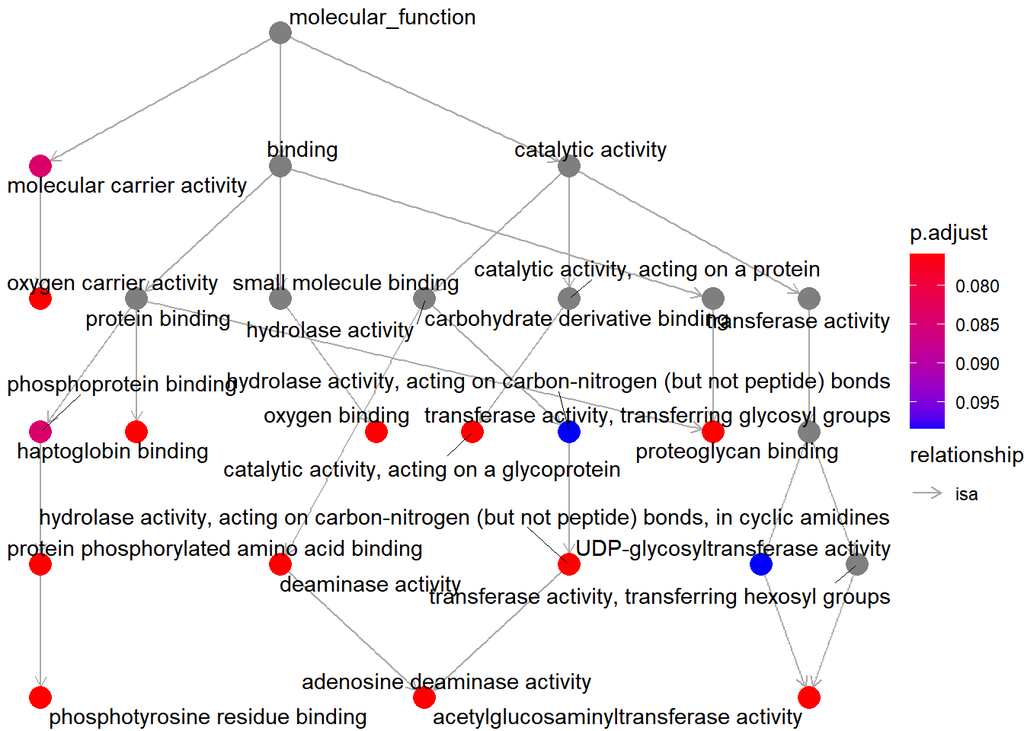

```r
goplot(ego2MF_SI)
```

```r
#Cellular Components
ego2CC_SI <- enrichGO(gene = names(geneList_DESeq2_SI), OrgDb = org.Hs.eg.db,
                      keyType = 'ENSEMBL', ont = "CC", pAdjustMethod = "BH",
                      pvalueCutoff  = 0.1, readable = T)

head(ego2CC_SI)
```

```
##                    ID                    Description GeneRatio   BgRatio
## GO:0031838 GO:0031838 haptoglobin-hemoglobin complex      1/10  11/22283
## GO:0005833 GO:0005833             hemoglobin complex      1/10  12/22283
## GO:0005770 GO:0005770                  late endosome      2/10 332/22283
## GO:0005767 GO:0005767             secondary lysosome      1/10  23/22283
## GO:0031045 GO:0031045             dense core granule      1/10  28/22283
## GO:0005771 GO:0005771            multivesicular body      1/10  65/22283
##                 pvalue   p.adjust     qvalue      geneID Count
## GO:0031838 0.004926540 0.05248878 0.03420321         HBD     1
## GO:0005833 0.005373322 0.05248878 0.03420321         HBD     1
## GO:0005770 0.009202856 0.05248878 0.03420321 CRHBP/PARM1     2
## GO:0005767 0.010276025 0.05248878 0.03420321       CRHBP     1
## GO:0031045 0.012497328 0.05248878 0.03420321       CRHBP     1
## GO:0005771 0.028796017 0.09817131 0.06397128       CRHBP     1
```

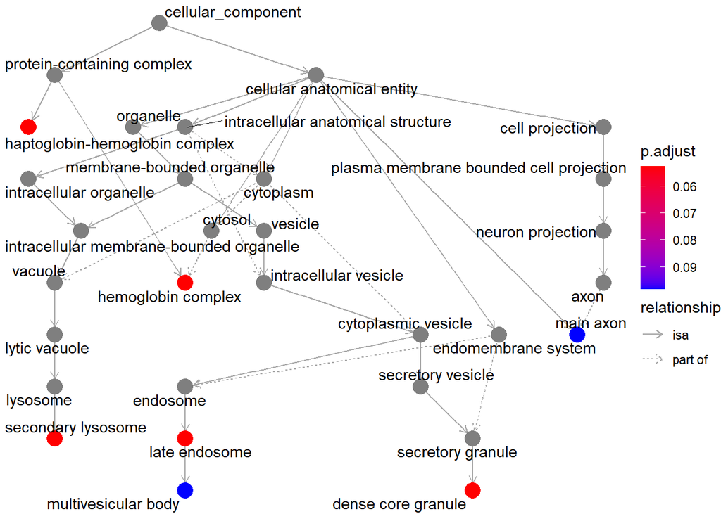

```r
goplot(ego2CC_SI)
```

```r
#Biological Process
ego2BP_SI <- enrichGO(gene = names(geneList_DESeq2_SI), OrgDb = org.Hs.eg.db,
                      keyType = 'ENSEMBL', ont = "BP", pAdjustMethod = "BH",
                      pvalueCutoff  = 0.1, readable = T)

head(ego2BP_SI)
```

```
##                    ID                                        Description
## GO:2000272 GO:2000272 negative regulation of signaling receptor activity
## GO:1990266 GO:1990266                               neutrophil migration
## GO:0097530 GO:0097530                              granulocyte migration
## GO:0010469 GO:0010469          regulation of signaling receptor activity
## GO:0002669 GO:0002669               positive regulation of T cell anergy
## GO:0002913 GO:0002913           positive regulation of lymphocyte anergy
##            GeneRatio   BgRatio      pvalue   p.adjust     qvalue     geneID
## GO:2000272       2/9  71/21069 0.000396964 0.06126149 0.03361228 CBLB/CRHBP
## GO:1990266       2/9 146/21069 0.001663006 0.06126149 0.03361228   XG/PREX1
## GO:0097530       2/9 174/21069 0.002350017 0.06126149 0.03361228   XG/PREX1
## GO:0010469       2/9 204/21069 0.003211525 0.06126149 0.03361228 CBLB/CRHBP
## GO:0002669       1/9  10/21069 0.004264386 0.06126149 0.03361228       CBLB
## GO:0002913       1/9  10/21069 0.004264386 0.06126149 0.03361228       CBLB
##            Count
## GO:2000272     2
## GO:1990266     2
## GO:0097530     2
## GO:0010469     2
## GO:0002669     1
## GO:0002913     1
```

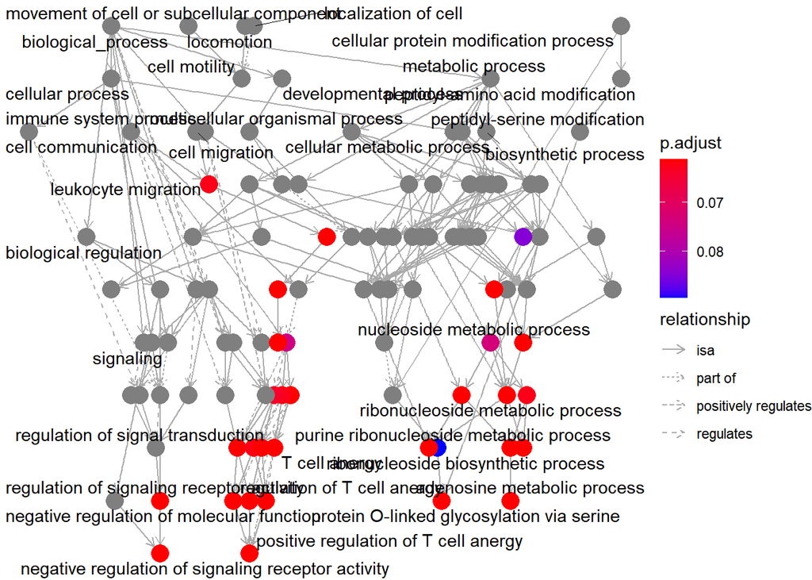

```r
goplot(ego2BP_SI)
```

#### **Kyoto Encyclopedia of Genes and Genomes (KEGG)**

In order to use the KEGG database, ENSEMBL ID are converted in ENTREZID. An higher p-value threshold (padj < 0.3) is needed for the Stenotic-Inflamed comparison because of the low number of DE genes having a smaller p-value.

```r
#INF VS NINF
gene_df2_IN <- bitr(names(geneList_DESeq2_IN), fromType = "ENSEMBL",
                 toType = "ENTREZID", OrgDb = org.Hs.eg.db)
geneList_df2_IN <- res2_inf_noninf$log2FoldChange
names(geneList_df2_IN) <- gene_df2_IN$ENTREZID

kk2_IN <- enrichKEGG(gene = gene_df2_IN$ENTREZID, organism = 'hsa', pvalueCutoff = 0.1)
head(kk2_IN)
```

```
##                ID                           Description GeneRatio  BgRatio
## hsa00230 hsa00230                     Purine metabolism       2/3 128/8390
## hsa00515 hsa00515    Mannose type O-glycan biosynthesis       1/3  23/8390
## hsa00510 hsa00510                 N-Glycan biosynthesis       1/3  49/8390
## hsa04923 hsa04923 Regulation of lipolysis in adipocytes       1/3  58/8390
## hsa04924 hsa04924                       Renin secretion       1/3  69/8390
## hsa01232 hsa01232                 Nucleotide metabolism       1/3  85/8390
##                pvalue    p.adjust      qvalue     geneID Count
## hsa00230 0.0006859488 0.008231386 0.002888206 51816/4881     2
## hsa00515 0.0082025268 0.049215161 0.017268477     146664     1
## hsa00510 0.0174207949 0.058734652 0.020608650     146664     1
## hsa04923 0.0205983753 0.058734652 0.020608650       4881     1
## hsa04924 0.0244727719 0.058734652 0.020608650       4881     1
## hsa01232 0.0300899974 0.059379571 0.020834937      51816     1
```

```r
#STEN VS NINF
gene_df2_SN <- bitr(names(geneList_DESeq2_SN), fromType = "ENSEMBL",
                 toType = "ENTREZID", OrgDb = org.Hs.eg.db)
geneList_df2_SN <- res2_sten_noninf$log2FoldChange
names(geneList_df2_SN) <- gene_df2_SN$ENTREZID

kk2_SN <- enrichKEGG(gene = gene_df2_SN$ENTREZID, organism = 'hsa', pvalueCutoff = 0.1)
head(kk2_SN)
```

```
##                ID                                                   Description
## hsa04061 hsa04061 Viral protein interaction with cytokine and cytokine receptor
## hsa00230 hsa00230                                             Purine metabolism
## hsa04060 hsa04060                        Cytokine-cytokine receptor interaction
## hsa04550 hsa04550      Signaling pathways regulating pluripotency of stem cells
## hsa04310 hsa04310                                         Wnt signaling pathway
## hsa04610 hsa04610                           Complement and coagulation cascades
##          GeneRatio  BgRatio       pvalue    p.adjust      qvalue
## hsa04061    11/205 100/8390 2.994316e-05 0.007934938 0.007091802
## hsa00230    12/205 128/8390 6.478323e-05 0.008583778 0.007671698
## hsa04060    18/205 295/8390 3.105528e-04 0.027432160 0.024517323
## hsa04550    11/205 143/8390 7.312589e-04 0.048445905 0.043298227
## hsa04310    12/205 171/8390 9.590259e-04 0.050727023 0.045336962
## hsa04610     8/205  86/8390 1.148536e-03 0.050727023 0.045336962
##                                                                                                geneID
## hsa04061                                    11009/4055/6354/8743/6376/3572/9547/1435/51554/3570/57007
## hsa00230                                   1633/5143/50808/4882/9060/115/2983/5137/111/4881/953/50940
## hsa04060 4804/11009/4055/6354/8743/6376/3572/9547/1435/51554/3570/652/151449/27242/3601/2690/57007/94
## hsa04550                                        7472/1432/6774/3572/8322/2260/652/4093/9314/2264/7482
## hsa04310                          7472/6424/102800317/4040/3725/85409/7088/340419/8322/5602/5176/7482
## hsa04610                                                         1191/7448/730/715/716/1675/3075/2155
##          Count
## hsa04061    11
## hsa00230    12
## hsa04060    18
## hsa04550    11
## hsa04310    12
## hsa04610     8
```

```r
#STEN VS INF
gene_df2_SI <- bitr(names(geneList_DESeq2_SI), fromType = "ENSEMBL",
                    toType = "ENTREZID", OrgDb = org.Hs.eg.db)
geneList_df2_SI <- res2_sten_inf$log2FoldChange
names(geneList_df2_SI) <- gene_df2_SI$ENTREZID

kk2_SI <- enrichKEGG(gene = gene_df2_SI$ENTREZID, organism = 'hsa', pvalueCutoff = 0.3)
head(kk2_SI)
```

```
##                ID                              Description GeneRatio  BgRatio
## hsa00515 hsa00515       Mannose type O-glycan biosynthesis       1/5  23/8390
## hsa00760 hsa00760   Nicotinate and nicotinamide metabolism       1/5  36/8390
## hsa00510 hsa00510                    N-Glycan biosynthesis       1/5  49/8390
## hsa01232 hsa01232                    Nucleotide metabolism       1/5  85/8390
## hsa04012 hsa04012                   ErbB signaling pathway       1/5  85/8390
## hsa04625 hsa04625 C-type lectin receptor signaling pathway       1/5 104/8390
##              pvalue  p.adjust     qvalue geneID Count
## hsa00515 0.01363508 0.1041434 0.07047297 146664     1
## hsa00760 0.02127582 0.1041434 0.07047297  54981     1
## hsa00510 0.02886913 0.1041434 0.07047297 146664     1
## hsa01232 0.04965109 0.1041434 0.07047297  51816     1
## hsa04012 0.04965109 0.1041434 0.07047297    868     1
## hsa04625 0.06047500 0.1041434 0.07047297    868     1
```

# Conclusions

#### **Pathway analysis discussion**

In the paper, by performing pathway analysis on the differentially methylated regions (DMRs) and differentially expressed genes (DEGs), they observed dysregulation of genes associated to **cellular differentiation**, **morphogenesis**, and **extracellular matrix remodeling**.

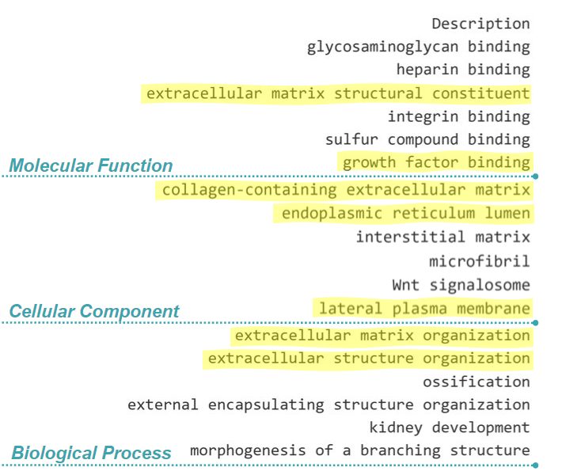

#### **DE genes**

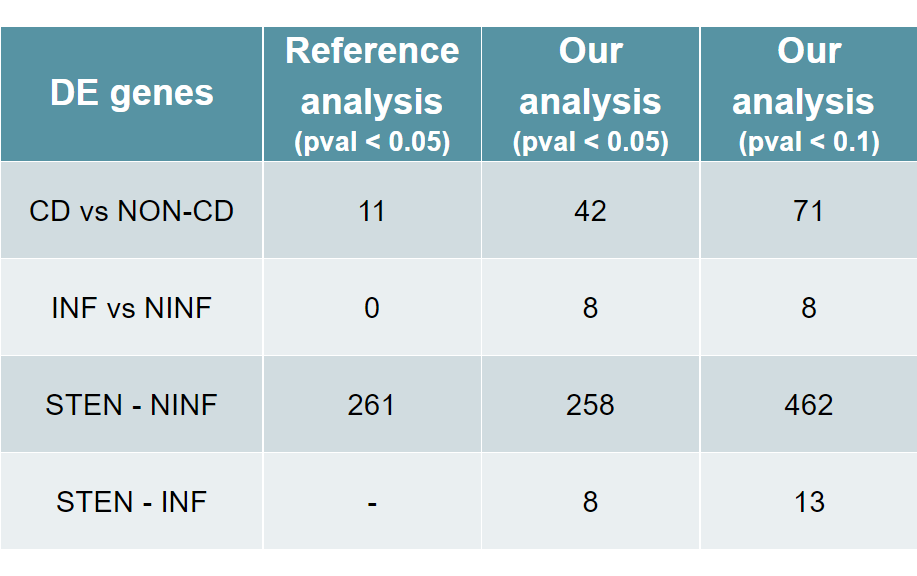

#### **Relevant genes**

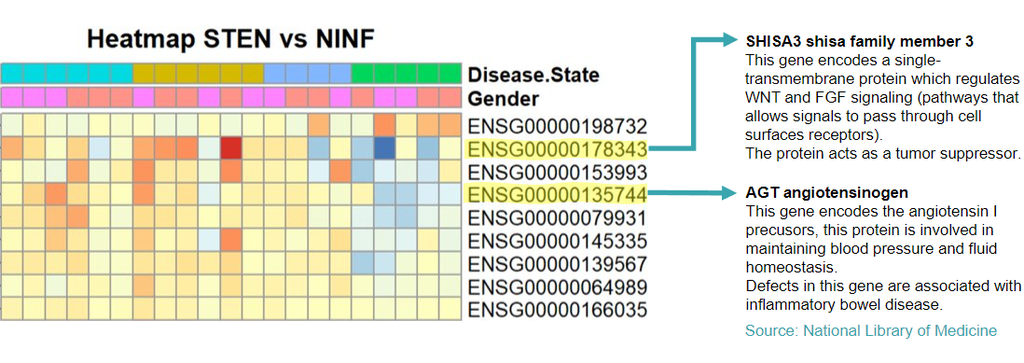

*To conclude our results are coherent with those obtained in the paper, as well as with the Crohn’s disease scenario. In particular, clear distinctions are observed when comparing stenotic and non-inflamed samples.*